# Reproducible Research: Peer Assessment 1

```r
knitr::opts_chunk$set(echo = TRUE, message = FALSE)
```

## Loading and preprocessing the data

```r
if(!file.exists("activity.csv"))
  unzip("activity.zip")
activityData <- read.csv("activity.csv", colClasses=c("integer", "Date", "integer"))
```

## What is mean total number of steps taken per day?

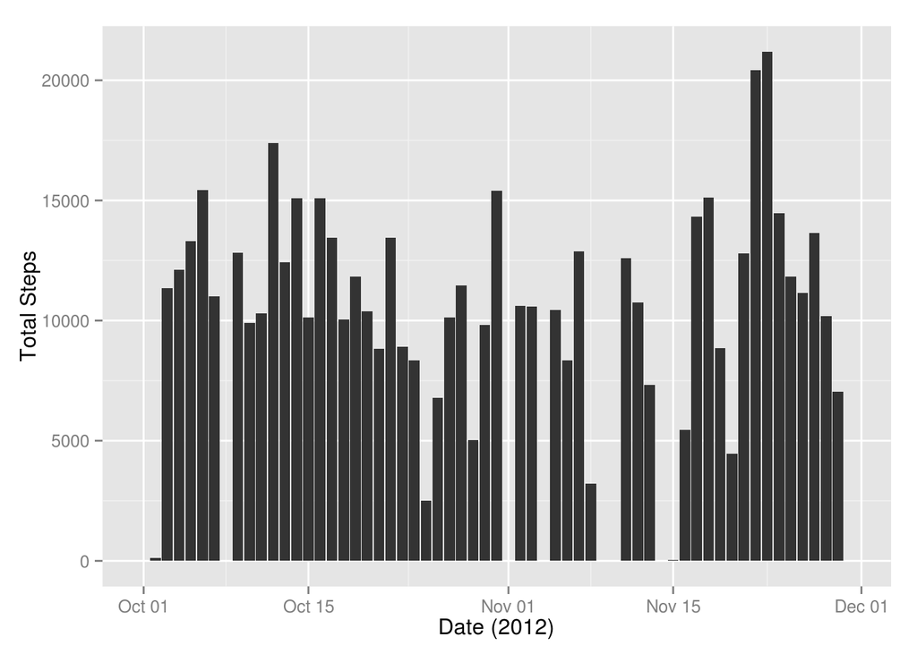

```r
require(ggplot2)
mean_median_plot <- function(activity) {
  daily_sum<-aggregate(activity$steps, by=list(activity$date), FUN=sum, na.rm=T)
  colnames(daily_sum) <- c("Date", "Total.Steps")

  daily_mean<-mean(daily_sum$Total.Steps, na.rm=T)
  daily_median<-median(daily_sum$Total.Steps, na.rm=T)

  print( qplot(daily_sum$Date, daily_sum$Total.Steps, geom="histogram", stat="identity",
               ylab="Total Steps", xlab="Date (2012)") )
  list(daily.mean=daily_mean, daily.median=daily_median)
}

daily_mean_median<-mean_median_plot(activityData)
```

The historgram chart show the total steps taken per day for all intervals, with **average** steps of 9354.2295082 with **median** of 10395 per day.

## What is the average daily activity pattern?

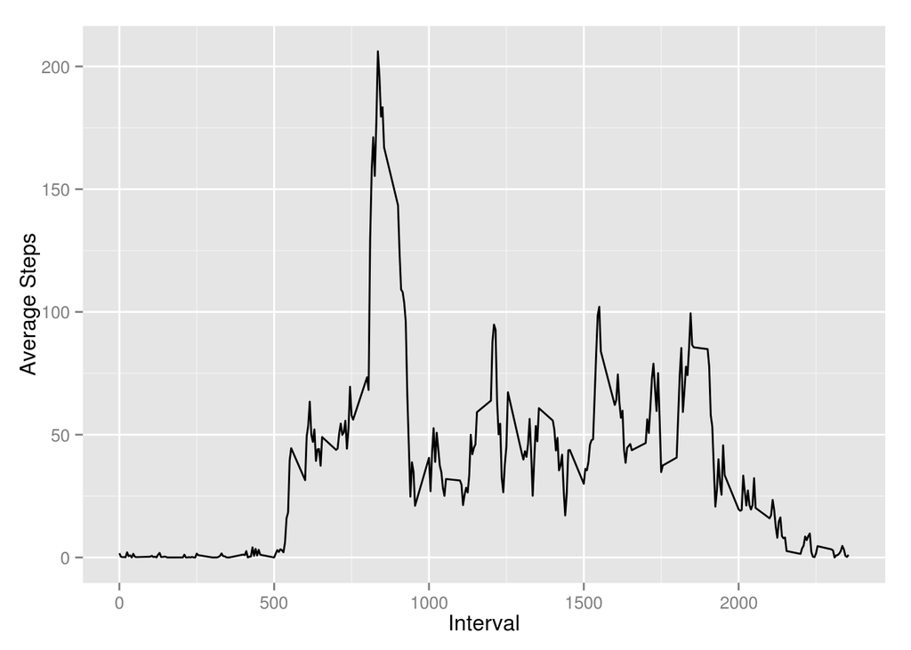

```r
daily_mean_interval<- aggregate(activityData$steps, by=list(activityData$interval), FUN=mean, na.rm=T)
colnames(daily_mean_interval)<- c("Interval", "Avg.Steps")

max_avg_interval<- subset(daily_mean_interval, Avg.Steps==max(daily_mean_interval$Avg.Steps))

qplot(Interval, Avg.Steps, data=daily_mean_interval,
      geom="line", ylab="Average Steps", xlab="Interval")
```

On average across all the days in the dataset, the 5-minute interval that contains the maximum number of steps was found in interval 835 with an average steps of 206.1698113.

## Imputing missing values

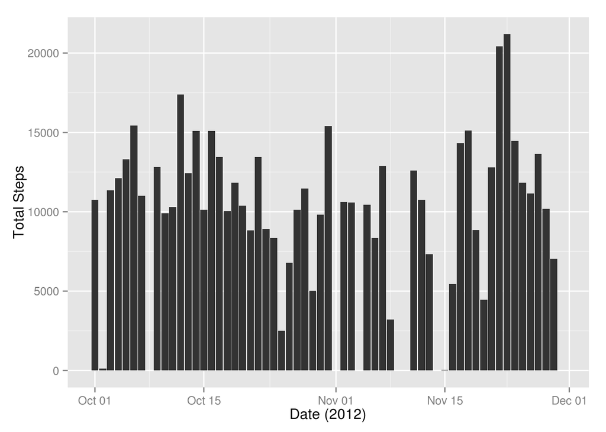

```r
total_missing_data<- sum(is.na(activityData$steps))

intr_to_impute <- subset(activityData, is.na(steps), interval)
intr_with_avg_steps <- sapply(intr_to_impute, FUN =
                      function(naI){
                        daily_mean_interval[daily_mean_interval$Interval==naI, "Avg.Steps"]
                      })

impute_activityData <- activityData
impute_activityData[is.na(impute_activityData$steps), "steps"] <- intr_with_avg_steps

imp_mean_median<-mean_median_plot(impute_activityData)
```

## Are there differences in activity patterns between weekdays and weekends?

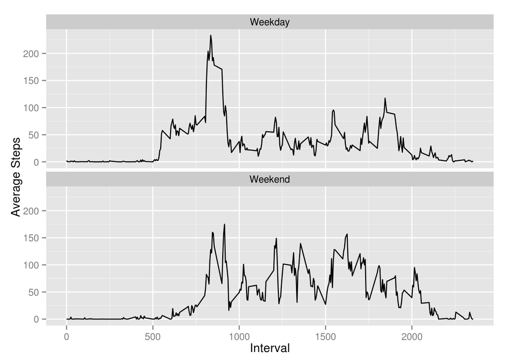

```r
week<- function(date) {
  require(lubridate)
  if(class(date) != "Date")
    stop("Require date type as param")
  sapply(date, function(d) {
    wd <-wday(d, label=T)
    if(wd == "Sun" || wd == "Sat")
      "Weekend"
    else
      "Weekday"
  })
}

impute_activityData$weekday<-as.factor(week(impute_activityData$date))
week_mean_interval<- aggregate(impute_activityData$steps, by=list(impute_activityData$weekday,
                                impute_activityData$interval), FUN=mean, na.rm=T)
colnames(week_mean_interval)<- c("Weekday", "Interval", "Avg.Steps")

qplot(Interval, Avg.Steps, data=week_mean_interval,
      geom="line", ylab="Average Steps", xlab="Interval") + facet_wrap(~Weekday, nrow = 2, ncol = 1)
```

Comparing Weekday and Weekend, the front interval of the day during weekday having more steps compare to weekend, where during weekend the steps distribution is more even during activity period.